# class14

Giulia Livrizzi

11/13/2019

```r
read.csv("airway_metadata.csv")
```

```
##           id     dex celltype     geo_id
## 1 SRR1039508 control   N61311 GSM1275862
## 2 SRR1039509 treated   N61311 GSM1275863
## 3 SRR1039512 control  N052611 GSM1275866
## 4 SRR1039513 treated  N052611 GSM1275867
## 5 SRR1039516 control  N080611 GSM1275870
## 6 SRR1039517 treated  N080611 GSM1275871
## 7 SRR1039520 control  N061011 GSM1275874
## 8 SRR1039521 treated  N061011 GSM1275875
```

```r
read.csv("airway_scaledcounts.csv")
```

[output not shown]

[output cut: 22210 more lines]

```r
counts <- read.csv("airway_scaledcounts.csv", stringsAsFactors = FALSE)
metadata <-  read.csv("airway_metadata.csv", stringsAsFactors = FALSE)
```

```r
head(counts)
```

```
##           ensgene SRR1039508 SRR1039509 SRR1039512 SRR1039513 SRR1039516
## 1 ENSG00000000003        723        486        904        445       1170
## 2 ENSG00000000005          0          0          0          0          0
## 3 ENSG00000000419        467        523        616        371        582
## 4 ENSG00000000457        347        258        364        237        318
## 5 ENSG00000000460         96         81         73         66        118
## 6 ENSG00000000938          0          0          1          0          2
##   SRR1039517 SRR1039520 SRR1039521
## 1       1097        806        604
## 2          0          0          0
## 3        781        417        509
## 4        447        330        324
## 5         94        102         74
## 6          0          0          0
```

```r
head(metadata)
```

```
##           id     dex celltype     geo_id
## 1 SRR1039508 control   N61311 GSM1275862
## 2 SRR1039509 treated   N61311 GSM1275863
## 3 SRR1039512 control  N052611 GSM1275866
## 4 SRR1039513 treated  N052611 GSM1275867
## 5 SRR1039516 control  N080611 GSM1275870
## 6 SRR1039517 treated  N080611 GSM1275871
```

#SETUP Bioconductor DESeq2

```r
install.packages("BiocManager")
BiocManager::install()
BiocManager::install("DESeq2")
```

```r
head(metadata)
```

```
##           id     dex celltype     geo_id
## 1 SRR1039508 control   N61311 GSM1275862
## 2 SRR1039509 treated   N61311 GSM1275863
## 3 SRR1039512 control  N052611 GSM1275866
## 4 SRR1039513 treated  N052611 GSM1275867
## 5 SRR1039516 control  N080611 GSM1275870
## 6 SRR1039517 treated  N080611 GSM1275871
```

how many genes do we have in this data set?

```r
nrow(counts)
```

```
## [1] 38694
```

how many experiments?

```r
ncol(counts)-1
```

```
## [1] 8
```

let’s make sure metadata id col matches the colnames of counts

```r
colnames(counts)[-1]
```

```
## [1] "SRR1039508" "SRR1039509" "SRR1039512" "SRR1039513" "SRR1039516"
## [6] "SRR1039517" "SRR1039520" "SRR1039521"
```

```r
metadata$id
```

```
## [1] "SRR1039508" "SRR1039509" "SRR1039512" "SRR1039513" "SRR1039516"
## [6] "SRR1039517" "SRR1039520" "SRR1039521"
```

```r
all(colnames(counts)[-1] ==metadata$id)
```

```
## [1] TRUE
```

all function to look across a vector of logicals

```r
all(c(T,T,T))
```

```
## [1] TRUE
```

#Analysis: compare averages of controls are different from treated averages. First we need to access the columns of our countdata that are control and then find their mean.

```r
metadata$dex =="control"
```

```
## [1]  TRUE FALSE  TRUE FALSE  TRUE FALSE  TRUE FALSE
```

#these are the columns I want to access

```r
control.id <-metadata[metadata$dex =="control", ]$id
control.id
```

```
## [1] "SRR1039508" "SRR1039512" "SRR1039516" "SRR1039520"
```

```r
head(counts[,control.id])
```

```
##   SRR1039508 SRR1039512 SRR1039516 SRR1039520
## 1        723        904       1170        806
## 2          0          0          0          0
## 3        467        616        582        417
## 4        347        364        318        330
## 5         96         73        118        102
## 6          0          1          2          0
```

#mean counts for control experiments(lenght(control.id) is number of columns -i.e. 4 here)

```r
control.mean <-rowSums(counts[,control.id])/length(control.id)
names(control.mean) <- counts$ensgene
```

#Do the same for drug treated exps

```r
treated <- metadata[metadata [,"dex"]=="treated",]
treated.mean <- rowSums(counts[, treated$id])/4
names(treated.mean) <- counts$ensgene
```

```r
meancounts <-data.frame(control.mean, treated.mean)
```

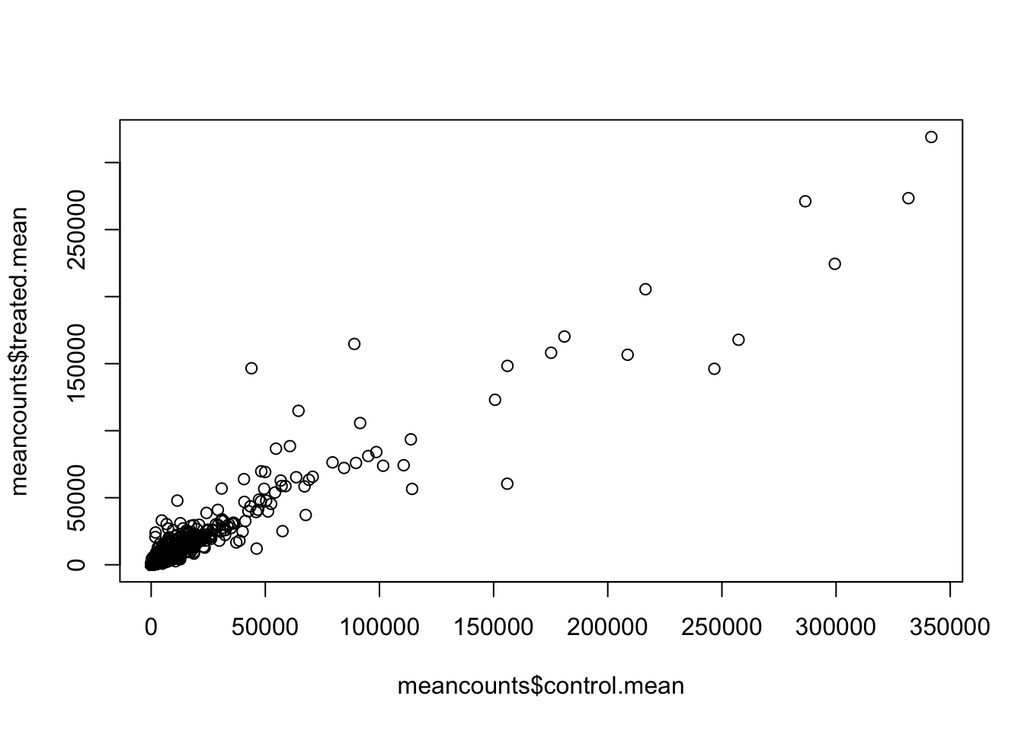

```r
plot(meancounts$control.mean, meancounts$treated.mean)
```

#Good case for a log plot

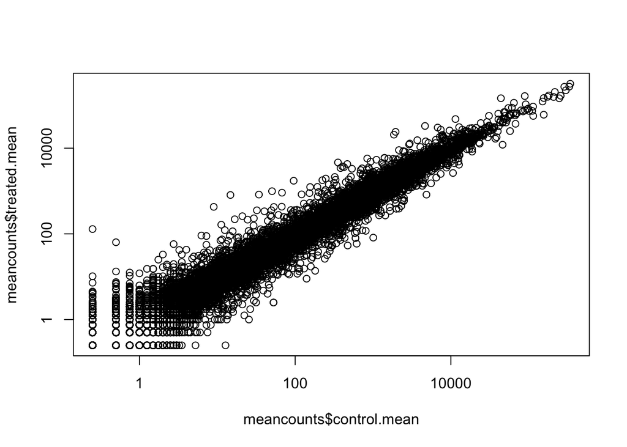

```r
plot(meancounts$control.mean, meancounts$treated.mean, log="xy")
```

#add new column called log2fc to see the fold change

```r
meancounts$log2fc <- log2(meancounts[,"treated.mean"]/meancounts[,"control.mean"])
head(meancounts)
```

```
##                 control.mean treated.mean      log2fc
## ENSG00000000003       900.75       658.00 -0.45303916
## ENSG00000000005         0.00         0.00         NaN
## ENSG00000000419       520.50       546.00  0.06900279
## ENSG00000000457       339.75       316.50 -0.10226805
## ENSG00000000460        97.25        78.75 -0.30441833
## ENSG00000000938         0.75         0.00        -Inf
```

#We want to remove NaN and the zero points from further analysis. Which will return only the values that you are looking for. #test for finding zero entries

```r
x<- c(5,8,0,5)
x==0
```

```
## [1] FALSE FALSE  TRUE FALSE
```

```r
which(x==0)
```

```
## [1] 3
```

```r
x<-data.frame(happy=c(5,6,0,0), sad=c(0,5,5,0))
x==0
```

```
##      happy   sad
## [1,] FALSE  TRUE
## [2,] FALSE FALSE
## [3,]  TRUE FALSE
## [4,]  TRUE  TRUE
```

#arr.ind gives you more insights on the position (row and column) of the NAN or zero values. you can use it even to just know the position of a gene. unique allows you to exclude those

```r
unique(which(x==0, arr.ind = TRUE)[,1])
```

```
## [1] 3 4 1
```

```r
inds<-unique(which(x==0, arr.ind = TRUE)[,1])
x[-inds,]
```

```
##   happy sad
## 2     6   5
```

#write another test

```r
x<-data.frame(analine=c(1,2,0,0), giulia=c(0,0,3,0))
x==0
```

```
##      analine giulia
## [1,]   FALSE   TRUE
## [2,]   FALSE   TRUE
## [3,]    TRUE  FALSE
## [4,]    TRUE   TRUE
```

```r
which(x==0, arr.ind = TRUE)
```

```
##      row col
## [1,]   3   1
## [2,]   4   1
## [3,]   1   2
## [4,]   2   2
## [5,]   4   2
```

```r
unique(which(x==0, arr.ind = TRUE)[,1])
```

```
## [1] 3 4 1 2
```

# now apply it to our metacounts data (i.e. removing NaNs and zero)

```r
to.rm<-unique(which(meancounts[,1:2]==0, arr.ind=TRUE)[,1])
mycounts <- meancounts[-to.rm,]
head(mycounts)
```

```
##                 control.mean treated.mean      log2fc
## ENSG00000000003       900.75       658.00 -0.45303916
## ENSG00000000419       520.50       546.00  0.06900279
## ENSG00000000457       339.75       316.50 -0.10226805
## ENSG00000000460        97.25        78.75 -0.30441833
## ENSG00000000971      5219.00      6687.50  0.35769358
## ENSG00000001036      2327.00      1785.75 -0.38194109
```

#How many genes do I have left?

```r
nrow(mycounts)
```

```
## [1] 21817
```

#A common threshold used for calling something differentially expressed is a log2(FoldChange) of greater than 2 or less than -2. Let’s filter the dataset both ways to see how many genes are up or down-regulated.

```r
up.ind <- mycounts$log2fc > 2
down.ind <- mycounts$log2fc < (-2)
```

#To count how many are left:

```r
sum(up.ind)
```

```
## [1] 250
```

```r
sum(down.ind)
```

```
## [1] 367
```

#In cases where you don’t have a preferred annotation file at hand you can use other Bioconductor packages for annotation. #Bioconductor’s annotation packages help with mapping various ID schemes to each other. Here we load the AnnotationDbi package and the annotation package org.Hs.eg.db.

```r
library("AnnotationDbi")
library("org.Hs.eg.db")
columns(org.Hs.eg.db)
```

```
##  [1] "ACCNUM"       "ALIAS"        "ENSEMBL"      "ENSEMBLPROT"
##  [5] "ENSEMBLTRANS" "ENTREZID"     "ENZYME"       "EVIDENCE"
##  [9] "EVIDENCEALL"  "GENENAME"     "GO"           "GOALL"
## [13] "IPI"          "MAP"          "OMIM"         "ONTOLOGY"
## [17] "ONTOLOGYALL"  "PATH"         "PFAM"         "PMID"
## [21] "PROSITE"      "REFSEQ"       "SYMBOL"       "UCSCKG"
## [25] "UNIGENE"      "UNIPROT"
```

```r
mycounts$symbol <- mapIds(org.Hs.eg.db,
                     keys=row.names(mycounts), # Our gene names
                     keytype="ENSEMBL",        # The format of our genenames
                     column="SYMBOL",          # The new format we want to add
                     multiVals="first")
head(mycounts)
```

```
##                 control.mean treated.mean      log2fc   symbol
## ENSG00000000003       900.75       658.00 -0.45303916   TSPAN6
## ENSG00000000419       520.50       546.00  0.06900279     DPM1
## ENSG00000000457       339.75       316.50 -0.10226805    SCYL3
## ENSG00000000460        97.25        78.75 -0.30441833 C1orf112
## ENSG00000000971      5219.00      6687.50  0.35769358      CFH
## ENSG00000001036      2327.00      1785.75 -0.38194109    FUCA2
```

#We still need to work on statistical tests. DESeq packages does everything we did for us included statistics. But in this way we learned a lot…

```r
library(DESeq2)
```

#We will use the DESeqDataSetFromMatrix() function to build the required DESeqDataSet object and call it dds, short for our DESeqDataSet.

```r
dds <- DESeqDataSetFromMatrix(countData=counts,
                              colData=metadata,
                              design=~dex,
                              tidy=TRUE)
dds <- DESeq(dds)
res<-results(dds)
res
```

```
## log2 fold change (MLE): dex treated vs control
## Wald test p-value: dex treated vs control
## DataFrame with 38694 rows and 6 columns
##                          baseMean     log2FoldChange             lfcSE
##                         <numeric>          <numeric>         <numeric>
## ENSG00000000003  747.194195359907 -0.350703020686579 0.168245681332529
## ENSG00000000005                 0                 NA                NA
## ENSG00000000419  520.134160051965  0.206107766417861 0.101059218008052
## ENSG00000000457  322.664843927049 0.0245269479387471 0.145145067649248
## ENSG00000000460   87.682625164828  -0.14714204922212 0.257007253994673
## ...                           ...                ...               ...
## ENSG00000283115                 0                 NA                NA
## ENSG00000283116                 0                 NA                NA
## ENSG00000283119                 0                 NA                NA
## ENSG00000283120 0.974916032393564  -0.66825846051647  1.69456285241871
## ENSG00000283123                 0                 NA                NA
##                               stat             pvalue              padj
##                          <numeric>          <numeric>         <numeric>
## ENSG00000000003   -2.0844696749953 0.0371174658432827 0.163034808641681
## ENSG00000000005                 NA                 NA                NA
## ENSG00000000419    2.0394751758463 0.0414026263001167 0.176031664879168
## ENSG00000000457  0.168982303952746  0.865810560623561 0.961694238404388
## ENSG00000000460  -0.57252099672319  0.566969065257939 0.815848587637724
## ...                            ...                ...               ...
## ENSG00000283115                 NA                 NA                NA
## ENSG00000283116                 NA                 NA                NA
## ENSG00000283119                 NA                 NA                NA
## ENSG00000283120 -0.394354484734893  0.693319342566817                NA
## ENSG00000283123                 NA                 NA                NA
```

#let’s make a vulcano plot: summary figures are frequently used to highlight the proportion of genes that are both significantly regulated and display a high fold change.Typically these plots shows the log fold change on the X-axis, and the −log10 of the p-value on the Y-axis (the more significant the p-value, the larger the −log10 of that value will be).

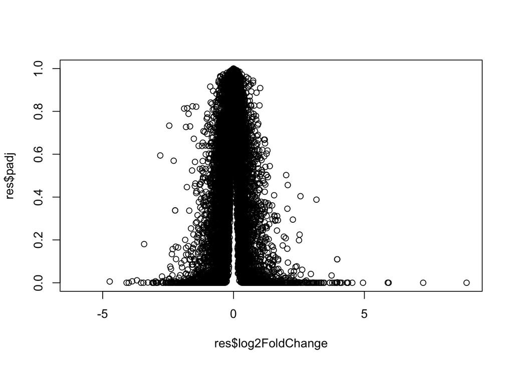

```r
plot(res$log2FoldChange, res$padj)
```

#the previous plot is not good because we are not seeing the data under p<0.05 which are the significant ones. Changing the axis would not work…we have to flip it adding -log. Points high up on the y-axis (above the horizontal line) are significantly regulated.

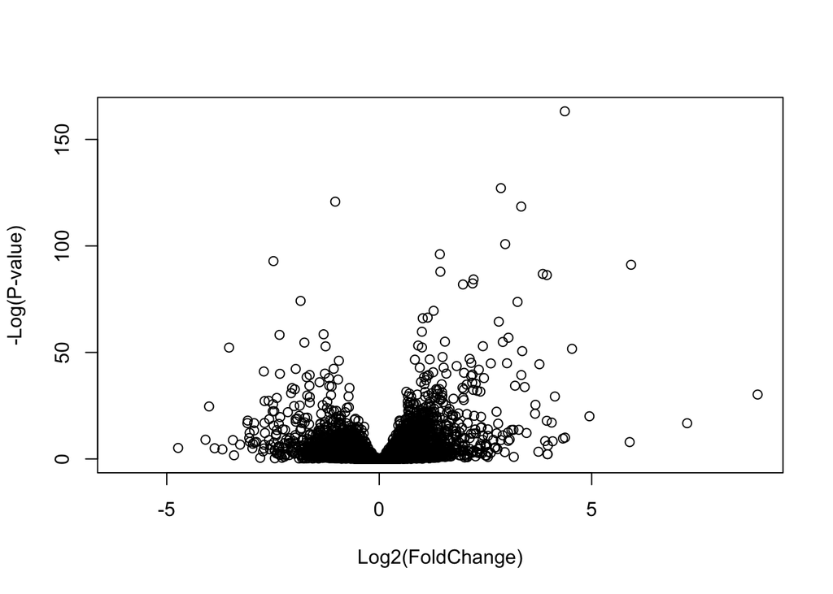

```r
plot( res$log2FoldChange,  -log(res$padj),
      xlab="Log2(FoldChange)",
      ylab="-Log(P-value)")
```

#We want color coding for significan changes and thresholds for -2 and 2 as well in the graph

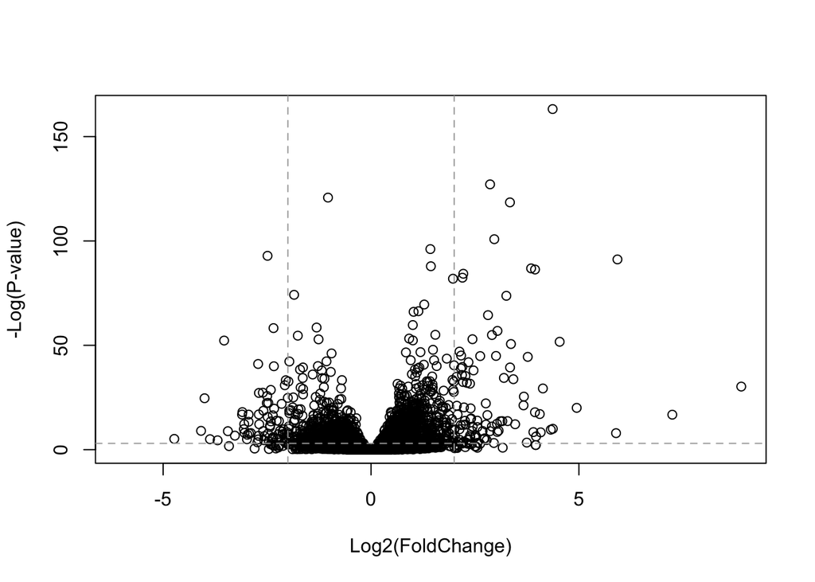

```r
plot(res$log2FoldChange,  -log(res$padj),
 ylab="-Log(P-value)", xlab="Log2(FoldChange)")
# Add some cut-off lines
abline(v=c(-2,2), col="darkgray", lty=2)
abline(h=-log(0.05), col="darkgray", lty=2)
```

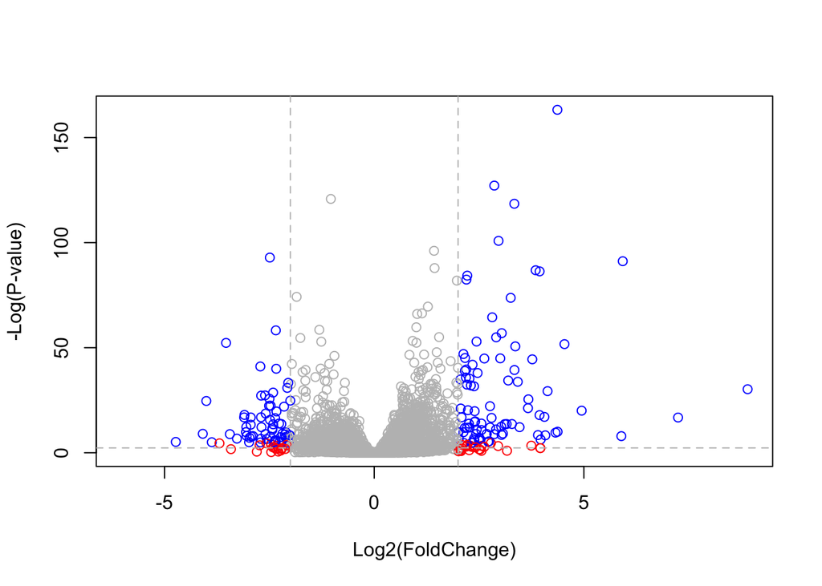

```r
# Setup our custom point color vector
mycols <- rep("gray", nrow(res))
mycols[ abs(res$log2FoldChange) > 2 ]  <- "red"

inds <- (res$padj < 0.01) & (abs(res$log2FoldChange) > 2 )
mycols[ inds ] <- "blue"

# Volcano plot with custom colors
plot( res$log2FoldChange,  -log(res$padj),
 col=mycols, ylab="-Log(P-value)", xlab="Log2(FoldChange)" )

# Cut-off lines
abline(v=c(-2,2), col="gray", lty=2)
abline(h=-log(0.1), col="gray", lty=2)
```